# GMS single cell practical 2 - Integration and dimension reduction

Charlotte Rich-Griffin

04/12/2020

This tutorial walks through an alignment of two groups of PBMCs from [Kang et al, 2017.](https://www.nature.com/articles/nbt.4042) In this experiment, PBMCs were split into a stimulated and control group and the stimulated group was treated with interferon beta. The response to interferon caused cell type specific gene expression changes that makes a joint analysis of all the data difficult, with cells clustering both by stimulation condition and by cell type.

# Load the data

```r
data(ifnb)
ifnb
```

```
## An object of class Seurat
## 14053 features across 13999 samples within 1 assay
## Active assay: RNA (14053 features, 0 variable features)
```

What does the metadata look like?

```r
ifnb@meta.data
```

[output not shown]

[output cut: 13945 more lines]

```
## TTTCTACTGGTATC.1  IMMUNE_STIM       1144          567 STIM       CD4 Memory T
## TTTCTACTTCAGAC.1  IMMUNE_STIM       1452          633 STIM                 NK
## TTTGACTGACGTAC.1  IMMUNE_STIM       1423          564 STIM        CD4 Naive T
## TTTGACTGATCACG.1  IMMUNE_STIM       2031          593 STIM          CD14 Mono
## TTTGACTGCCCACT.1  IMMUNE_STIM       2751          743 STIM          CD14 Mono
## TTTGACTGCCCTAC.1  IMMUNE_STIM       2403          722 STIM          CD14 Mono
## TTTGACTGCTACCC.1  IMMUNE_STIM       1978          745 STIM        CD4 Naive T
## TTTGACTGCTTGGA.1  IMMUNE_STIM       1417          510 STIM       CD4 Memory T
## TTTGACTGGCGAAG.1  IMMUNE_STIM       2205          760 STIM                  B
## TTTGACTGGGTACT.1  IMMUNE_STIM       1123          507 STIM                  B
## TTTGCATGAACGAA.1  IMMUNE_STIM       5577         1237 STIM                 DC
## TTTGCATGACGTAC.1  IMMUNE_STIM       1364          536 STIM       CD4 Memory T
## TTTGCATGCCTGTC.1  IMMUNE_STIM       2114          817 STIM                  B
## TTTGCATGCTAAGC.1  IMMUNE_STIM       1522          523 STIM        CD4 Naive T
## TTTGCATGGGACGA.1  IMMUNE_STIM       1143          503 STIM        CD4 Naive T
```

In this datase, the two samples are labelled CTRL and STIM. This data set has already been quality controlled but we can take a quick look at the QC metrics. *Make Violin plots for nCount_RNA and nFeature_RNA* *Look up in the documentation how to group the plots by different samples*

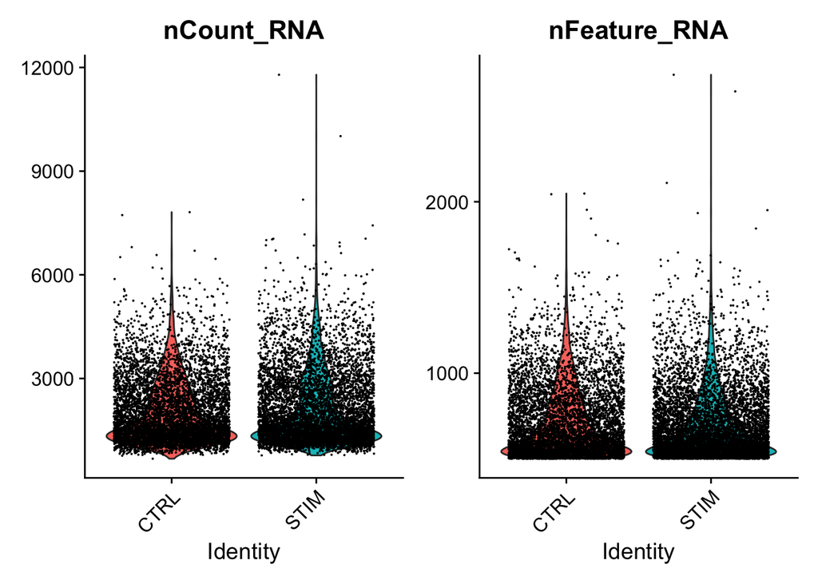

```r
VlnPlot(ifnb, features = c('nCount_RNA', 'nFeature_RNA'),group.by ="stim", pt.size = 0.01)
```

*Make a scatter plot compaing nCount_RNA and nFeature_RNA*

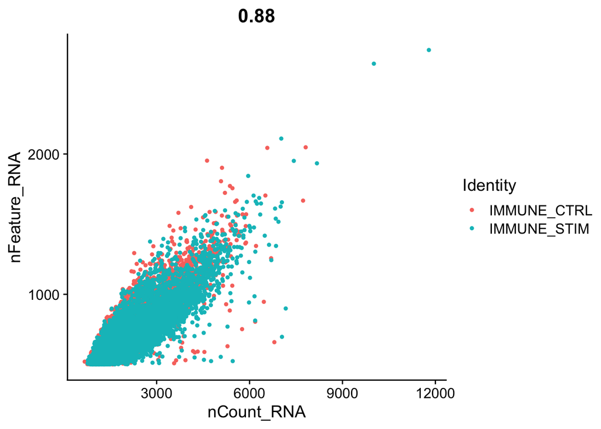

```r
FeatureScatter(ifnb, feature1 = "nCount_RNA", feature2 = "nFeature_RNA")
```

Based on these plots, are we happy about the filtering that has been done?

Some of the integration steps are quite computationally intensive, so if you were running this in “real life” you will probably need to get access to some High Performance Comuting facilities.

For the purposes of today, we are going to sample our data down so we can run it locally

```r
set.seed(42)
ifnb = subset(ifnb, cells = sample(Cells(ifnb), 4000))
# check we have approximately equal CTRL and STIM cells
table(ifnb@meta.data$stim)
```

```
##
## CTRL STIM
## 1867 2133
```

# Integrate and Normalise Data

Two options are available from Seurat for integration and noramlisation of data: - Standard Workflow - SCTransform

Why integrate data?

Integration is also referred to as batch correction, as you are essentially trying to merge your samples. What are some potential source of batch effects? How might you mitigate vbatch effects with experimental design?

## Standard Workflows:

1. Split the dataset in two, and run normal normalisation steps.

```r
ifnb.list <- SplitObject(ifnb, split.by = "stim")

ifnb.list <- lapply(X = ifnb.list, FUN = function(x) {
    x <- NormalizeData(x)
    x <- FindVariableFeatures(x, selection.method = "vst", nfeatures = 2000)
})
```

```r
immune.anchors <- FindIntegrationAnchors(object.list = ifnb.list, dims = 1:20)
```

```
## Computing 2000 integration features
```

```
## Scaling features for provided objects
```

```
## Finding all pairwise anchors
```

```
## Running CCA
```

```
## Merging objects
```

```
## Finding neighborhoods
```

```
## Finding anchors
```

```
##  Found 5295 anchors
```

```
## Filtering anchors
```

```
##  Retained 3510 anchors
```

```r
str(immune.anchors, max.level = 3)
```

```
## Formal class 'AnchorSet' [package "Seurat"] with 8 slots
##   ..@ object.list      :List of 2
##   .. ..$ CTRL:Formal class 'Seurat' [package "Seurat"] with 13 slots
##   .. ..$ STIM:Formal class 'Seurat' [package "Seurat"] with 13 slots
##   ..@ reference.cells  : logi(0)
##   ..@ reference.objects: int [1:2] 1 2
##   ..@ query.cells      : logi(0)
##   ..@ anchors          :'data.frame':    7020 obs. of  5 variables:
##   .. ..$ cell1   : num [1:7020] 1 1 1 1 2 2 2 3 4 5 ...
##   .. ..$ cell2   : num [1:7020] 1626 395 1993 1970 110 ...
##   .. ..$ score   : num [1:7020] 0.938 0.499 0.938 0.792 0.587 ...
##   .. ..$ dataset1: int [1:7020] 1 1 1 1 1 1 1 1 1 1 ...
##   .. ..$ dataset2: int [1:7020] 2 2 2 2 2 2 2 2 2 2 ...
##   ..@ offsets          : num [1:2] 0 1867
##   ..@ anchor.features  : chr [1:2000] "CCL4" "CCL3" "GNLY" "CCL7" ...
##   ..@ command          :Formal class 'SeuratCommand' [package "Seurat"] with 5 slots
```

3. Integrate!

```r
immune.combined <- IntegrateData(anchorset = immune.anchors, dims = 1:20)
```

```
## Merging dataset 1 into 2
```

```
## Extracting anchors for merged samples
```

```
## Finding integration vectors
```

```
## Finding integration vector weights
```

```
## Integrating data
```

```r
Assays(immune.combined)
```

```
## [1] "RNA"        "integrated"
```

We can see that `immune.combined` has a new assay called `integrated`. We will run dimension reduction methods on the `integrated` assay. Now we can run dimension reduction on the `integrated` assay.

```r
DefaultAssay(immune.combined) <- "integrated"
# Run the standard workflow for visualization and clustering
immune.combined <- ScaleData(immune.combined, verbose = FALSE)
immune.combined <- RunPCA(immune.combined, npcs = 30, verbose = FALSE)
immune.combined <- RunUMAP(immune.combined, reduction = "pca", dims = 1:20)
```

```r
p1 <- UMAPPlot(immune.combined, group.by="stim" )
```

For our dataset we can compare what the UMAP would look like with and without integration.

First we must run dimension resduction on out original `ifnb` object.

```r
# quickly run the prerequisite steps for UMAP on our original data
ifnb <- FindVariableFeatures(ifnb, nfeatures = 2000)
ifnb <- ScaleData(ifnb)
ifnb <- RunPCA(ifnb)
```

```
## PC_ 1
## Positive:  TYROBP, S100A11, TYMP, ANXA5, FCER1G, CD63, IFITM3, ANXA2, SDCBP, FTL
##     ISG15, CST3, NPC2, S100A10, SOD2, APOBEC3A, C15orf48, DYNLT1, PSAP, CTSS
##     KYNU, LGALS1, PLSCR1, RSAD2, IGSF6, CTSB, FTH1, NINJ1, CXCL11, CD68
## Negative:  CD3D, LTB, CD7, GIMAP7, NPM1, SELL, PTPRCAP, TRAT1, PIK3IP1, RHOH
##     ITM2A, CD3G, LEF1, IL32, PASK, SYNE2, GPR171, CLEC2D, NHP2, PBXIP1
##     RGCC, TMEM243, SNHG8, ALOX5AP, TSC22D3, NOP58, CD8B, SRM, CD27, NKG7
## PC_ 2
## Positive:  ISG20, IFIT3, IFIT1, LY6E, IFI6, MX1, ISG15, TNFSF10, IFIT2, IFITM3
##     CXCL10, OAS1, RSAD2, CXCL11, IRF7, OASL, IFITM2, APOBEC3A, MT2A, PLSCR1
##     DDX58, GBP1, TNFSF13B, CMPK2, SAMD9L, GBP4, DYNLT1, RABGAP1L, IFIH1, FAM26F
## Negative:  PFN1, IL8, CLEC5A, GAPDH, ACTB, FTH1, GPX1, S100A8, IER3, PLAUR
##     CD14, VCAN, S100A6, PID1, VIM, MARCKSL1, LIMS1, CEBPB, TIMP1, TALDO1
##     PPIF, S100A4, CD9, S100A9, PHLDA1, SLC7A11, FTL, OLR1, INSIG1, COTL1
## PC_ 3
## Positive:  CD74, HLA-DQA1, HLA-DRA, HLA-DPB1, HLA-DPA1, HLA-DQB1, HLA-DRB1, CCR7, CD83, GPR183
##     SYNGR2, BIRC3, TXN, HLA-DMA, HSP90AB1, REL, NPM1, HSPD1, PPA1, GPR137B
##     HERPUD1, CCT2, ID2, SERPINB1, LSP1, FABP5, CST7, PRMT1, SEC61B, CYCS
## Negative:  FCER1G, S100A8, S100A9, CD300E, CCL2, CD14, MAFB, C3AR1, CTSL, FCN1
##     FTH1, CFD, HPSE, GLUL, C5AR1, FTL, CTSB, CTSD, PLAUR, TYROBP
##     RP11-290F20.3, NPC2, CCL8, AIF1, CLEC4E, S100A4, CD68, PLA2G7, SOD2, SERPINA1
## PC_ 4
## Positive:  FCGR3A, MS4A7, VMO1, CXCL16, HN1, LST1, MS4A4A, ATP1B3, PPM1N, PLAC8
##     SERPINA1, AIF1, VASP, COTL1, CD86, CASP5, C3AR1, GBP5, PILRA, RP11-290F20.3
##     SMPDL3A, LRRC25, JUNB, CDKN1C, CFD, VNN2, LILRA5, LTA4H, ADA, HCAR3
## Negative:  CCL2, CCL8, CTSB, RSAD2, CCL7, CSTB, PLA2G7, CCR1, CTSL, IDO1
##     CD63, CAPG, CREG1, HPSE, VIM, FTL, S100A10, LGALS3, IL1RN, CCR5
##     LMNA, SDS, EMP1, LGALS1, FPR3, S100A9, TPM4, HSPA1A, LILRB4, ISG15
## PC_ 5
## Positive:  HSP90AB1, HSPD1, SRSF7, HSPE1, HSPA8, SRSF2, NOP58, NPM1, CACYBP, CKS2
##     NME1, CCT2, CREM, HSPH1, TCP1, FKBP4, SNHG15, CHORDC1, DDX21, CYCS
##     PRDX1, MIR155HG, MYC, NOP56, SNHG12, NHP2, YPEL5, HSP90AA1, SNHG8, RPL22L1
## Negative:  HLA-DPB1, CD74, CST7, HLA-DPA1, LSP1, HLA-DRA, HLA-DRB1, SERPINB1, CALCRL, MARCKSL1
##     TXN, GPR137B, CCL22, RAB9A, CST3, FAM49A, FSCN1, ALDH2, CCR7, RAMP1
##     GPR157, DAPP1, GSN, HLA-DQA1, HLA-DQB1, RHOF, PKIB, ID2, OGFRL1, IDO1
```

```r
ifnb <- RunUMAP(ifnb, reduction = "pca", dims=1:50)
```

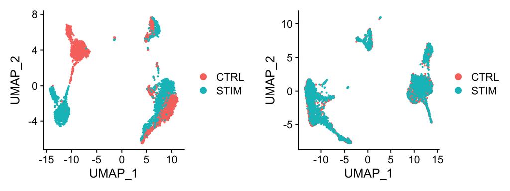

```r
# no integration
p1 <- UMAPPlot(ifnb, group.by="stim" )
# Integrated
p2 <- UMAPPlot(immune.combined, group.by="stim")
plot_grid(p1, p2)
```

### SCTransform

The alternative normalisation method SCTransform can be used to do this integration using the following code, maybe try it out in your own time. The method and it’s benefits are discussed in the [preprint](https://www.biorxiv.org/content/10.1101/576827v2) and a separate [vignette](https://satijalab.org/seurat/v3.0/sctransform_vignette.html)

```r
# for (i in 1:length(ifnb.list)) {
#     ifnb.list[[i]] <- SCTransform(ifnb.list[[i]], verbose = FALSE)
# }
# immune.features <- SelectIntegrationFeatures(object.list = ifnb.list, nfeatures = 3000)
# immune.list <- PrepSCTIntegration(object.list = ifnb.list, anchor.features = immune.features,
#     verbose = FALSE)
#
# immune.anchors.sct <- FindIntegrationAnchors(object.list = immune.list, dims = 1:20,  anchor.features = immune.features, normalization.method = "SCT")
#
# immune.combined.sct <- IntegrateData(anchorset = immune.anchors, normalization.method = "SCT",
#     verbose = FALSE)
```

## Other methods

There are also a host of other methods, one of the most popular current tools is Harmony [github](https://github.com/immunogenomics/harmony) [paper](https://www.nature.com/articles/s41592-019-0619-0)

One last comment about integration before we move on. Lots of different methods work in different ways! Different methods work better on different datasets. Methods of benchmarking different batch correction/integration techniques are discussed in this [paper](https://genomebiology.biomedcentral.com/articles/10.1186/s13059-019-1850-9) The main thing I would recommend is always look at your dimension reduction plots to compare how different methods are acting on your dataset.

# Dimension reduction and clustering

Having integrated our dataset, we can get back to trying to visualise our data set

UMAP and Clustering

```r
immune.combined <- RunUMAP(immune.combined, reduction = "pca", dims = 1:20)
immune.combined <- FindNeighbors(immune.combined, reduction = "pca", dims = 1:20)
immune.combined <- FindClusters(immune.combined, resolution = 0.5)
```

```
## Modularity Optimizer version 1.3.0 by Ludo Waltman and Nees Jan van Eck
##
## Number of nodes: 4000
## Number of edges: 162338
##
## Running Louvain algorithm...
## Maximum modularity in 10 random starts: 0.8932
## Number of communities: 13
## Elapsed time: 0 seconds
```

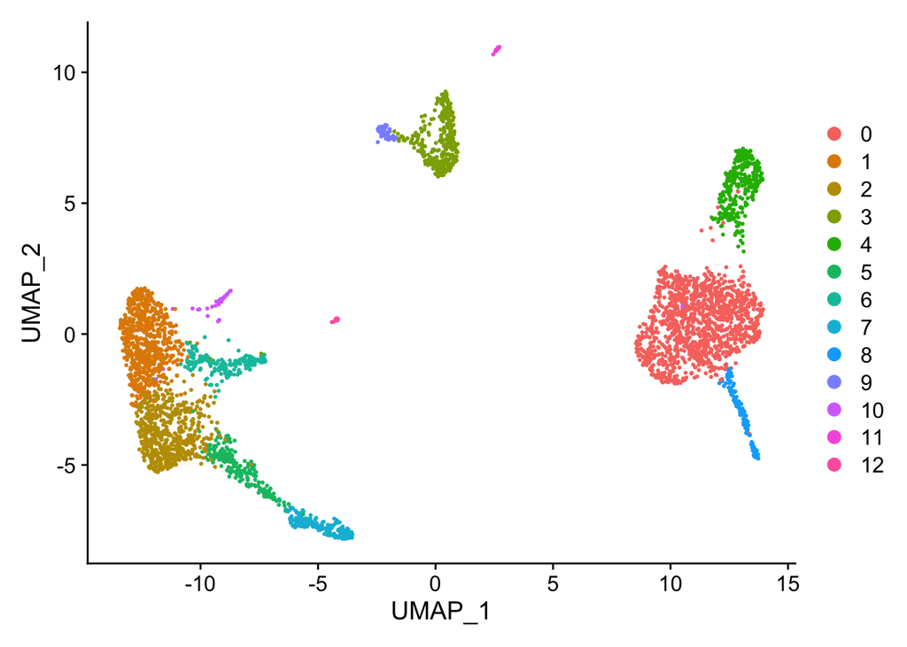

```r
UMAPPlot(immune.combined)
```

## A word about Parameters

But what a parameters are the “best” parameters? Answer :shrug_emoji: it depends!!

Key parameters:

FindClusters: - resolution (try some different resolutions in the range or 0.5 to 1.5, the more cells in teh data set the higher the most appropriate resolution. The `clustree visualisation can help work this out

```r
plts <- list()
res_opt <- c(0.1, 0.2, 0.4, 0.6, 0.8, 1)
for(res in res_opt){
    print(res)
    immune.combined <- FindClusters(immune.combined, resolution = res)
    plts[[as.character(res)]] <- UMAPPlot(immune.combined, group.by=paste0("integrated_snn_res.", res)) + ggtitle(paste("resolution", res))

}
```

```
## [1] 0.1
## Modularity Optimizer version 1.3.0 by Ludo Waltman and Nees Jan van Eck
##
## Number of nodes: 4000
## Number of edges: 162338
##
## Running Louvain algorithm...
## Maximum modularity in 10 random starts: 0.9656
## Number of communities: 6
## Elapsed time: 0 seconds
## [1] 0.2
## Modularity Optimizer version 1.3.0 by Ludo Waltman and Nees Jan van Eck
##
## Number of nodes: 4000
## Number of edges: 162338
##
## Running Louvain algorithm...
## Maximum modularity in 10 random starts: 0.9417
## Number of communities: 10
## Elapsed time: 0 seconds
## [1] 0.4
## Modularity Optimizer version 1.3.0 by Ludo Waltman and Nees Jan van Eck
##
## Number of nodes: 4000
## Number of edges: 162338
##
## Running Louvain algorithm...
## Maximum modularity in 10 random starts: 0.9088
## Number of communities: 13
## Elapsed time: 0 seconds
## [1] 0.6
## Modularity Optimizer version 1.3.0 by Ludo Waltman and Nees Jan van Eck
##
## Number of nodes: 4000
## Number of edges: 162338
##
## Running Louvain algorithm...
## Maximum modularity in 10 random starts: 0.8793
## Number of communities: 14
## Elapsed time: 0 seconds
## [1] 0.8
## Modularity Optimizer version 1.3.0 by Ludo Waltman and Nees Jan van Eck
##
## Number of nodes: 4000
## Number of edges: 162338
##
## Running Louvain algorithm...
## Maximum modularity in 10 random starts: 0.8554
## Number of communities: 14
## Elapsed time: 0 seconds
## [1] 1
## Modularity Optimizer version 1.3.0 by Ludo Waltman and Nees Jan van Eck
##
## Number of nodes: 4000
## Number of edges: 162338
##
## Running Louvain algorithm...
## Maximum modularity in 10 random starts: 0.8352
## Number of communities: 15
## Elapsed time: 0 seconds
```

```r
# the new resoltuoins have been automatically saved in the metadata
colnames(immune.combined@meta.data)
```

```
##  [1] "orig.ident"             "nCount_RNA"             "nFeature_RNA"
##  [4] "stim"                   "seurat_annotations"     "integrated_snn_res.0.5"
##  [7] "seurat_clusters"        "integrated_snn_res.0.1" "integrated_snn_res.0.2"
## [10] "integrated_snn_res.0.4" "integrated_snn_res.0.6" "integrated_snn_res.0.8"
## [13] "integrated_snn_res.1"
```

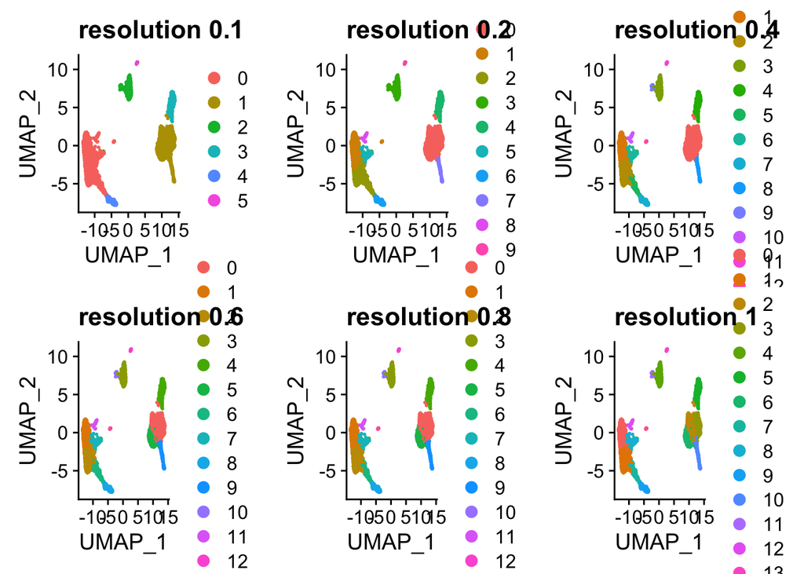

```r
plot_grid(plotlist = plts)
```

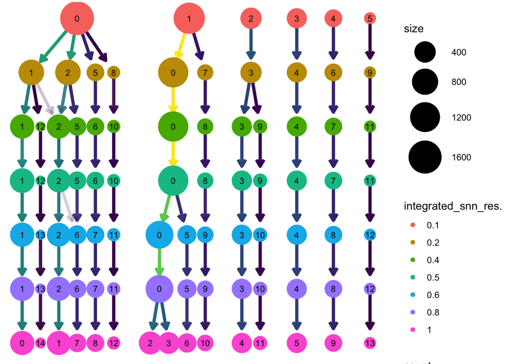

```r
library(clustree)
clustree(immune.combined)
```

Other parameters you should investigate in your own datasets are: FindNeighbours: - k.param (this is the number of neighbours that you find per cell)

RunUMAP: - n.neighbours (This determines the number of neighboring points used in local approximations of manifold structure. Larger values will result in more global structure being preserved at the loss of detailed local structure. In general this parameter should often be in the range 5 to 50.) - min.dist (This controls how tightly the embedding is allowed compress points together. Larger values ensure embedded points are moreevenly distributed, while smaller values allow the algorithm to optimise more accurately with regard to local structure. Sensible values are in the range 0.001 to 0.5.)

Many of the parameters can influence each other, so you may have to take an iteratvie appraoch to find the “best parameters for your data”

Let’s save our data set here

```r
saveRDS(immune.combined, file = "~/gms/data/ifnb_integrated.rds")
```

Now let’s move on to finding cluster markers.